# Downloading and Prepping Data

# No Death Imapct States

Puducherry, Ladakh, Mizoram, Uttarakhand, & Andaman and Nicobar Islands have not reported any death by coronavirus so far.

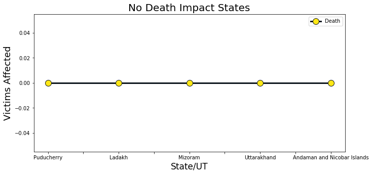

```python
lddf.plot(kind='line',figsize=(11,5),
           color='#101820FF',
           marker='o',
           markersize=12,
           markerfacecolor='#FEE715FF',
           linewidth=3)
plt.title('No Death Impact States',fontsize=20)
plt.xlabel('State/UT',fontsize=17)
plt.ylabel('Victims Affected',fontsize=18)
plt.show()
```

# Scatter Plot Against Total

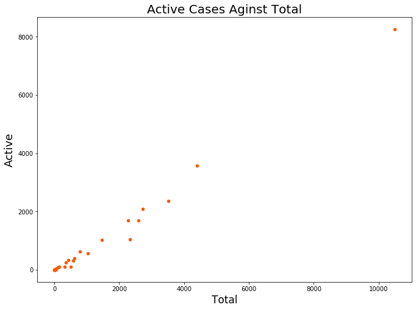

```python
df.plot(kind='scatter', x='Total',y='Active',figsize=(11,8),color='#F95700FF')
plt.title('Active Cases Aginst Total',fontsize=20)
plt.xlabel('Total',fontsize=17)
plt.ylabel('Active',fontsize=18)
plt.show()
```

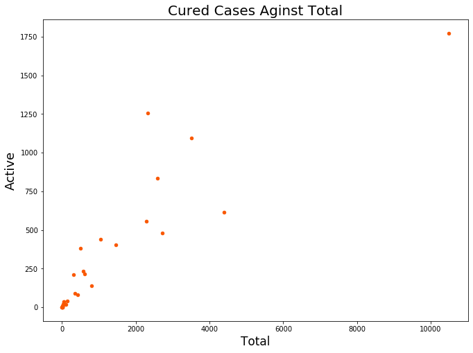

```python
df.plot(kind='scatter', x='Total',y='Cured',figsize=(11,8),color='#F95700FF')
plt.title('Cured Cases Aginst Total',fontsize=20)
plt.xlabel('Total',fontsize=17)
plt.ylabel('Active',fontsize=18)
plt.show()
```

[figure not shown]

```python
df.plot(kind='scatter', x='Total',y='Death',figsize=(11,8),color='#00539CFF',marker='o')
plt.title('Cured Cases Aginst Total',fontsize=20)
plt.xlabel('Total',fontsize=17)
plt.ylabel('Active',fontsize=18)
plt.show()
```

# Regression between Active and Total

Even though we know that, if total cases increase the active cases will also increase, to better understand the data from data set between active cases and total corona cases I have used the regression plot. In the regression plot, we can see a straight line passes through the active cases and total cases in India.

[figure not shown]

```python
plt.figure(figsize=(11,8))

sns.set(font_scale=1.5)
ax = sns.regplot(x='Total',y='Active',data=df,color='#F95700FF')
ax.set(xlabel='Total', ylabel='Active')
ax.set_title('Regression Plot between Active and Total')
```

# Area Plot

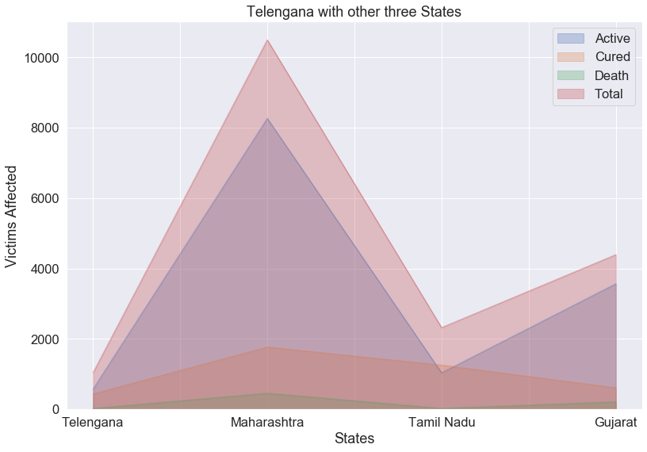

```python
compa.plot(kind='area',
             alpha=0.3, # 0-1, default value a= 0.5
             stacked=False,
             figsize=(13, 9),
            )

plt.title('Telengana with other three States')
plt.ylabel('Victims Affected')
plt.xlabel('States')

plt.show()
```

# Geo-Sapatial Visualization of COVID-19 IN INDIA

```python
pwd
```

```
'/Users/nagapurnithinreddy/Downloads/COVID'
```

```python
cd
```

```
/Users/nagapurnithinreddy
```

```python
idc = open('Indian Coordinates.csv')
```

```python
idf = pd.read_csv(idc)
```

```python
idf
```

|  | Name of State / UT | Latitude | Longitude |
| --- | --- | --- | --- |
| 0 | Andaman and Nicobar Islands | 11.667026 | 92.735983 |
| 1 | Andhra Pradesh | 14.750429 | 78.570026 |
| 2 | Arunachal Pradesh | 27.100399 | 93.616601 |
| 3 | Assam | 26.749981 | 94.216667 |
| 4 | Bihar | 25.785414 | 87.479973 |
| 5 | Chandigarh | 30.719997 | 76.780006 |
| 6 | Chhattisgarh | 22.090420 | 82.159987 |
| 7 | Delhi | 28.669993 | 77.230004 |
| 8 | Goa | 15.491997 | 73.818001 |
| 9 | Gujarat | 22.258700 | 71.192400 |
| 10 | Haryana | 28.450006 | 77.019991 |
| 11 | Himachal Pradesh | 31.100025 | 77.166597 |
| 12 | Jammu and Kashmir | 33.450000 | 76.240000 |
| 13 | Jharkhand | 23.800393 | 86.419986 |
| 14 | Karnataka | 12.570381 | 76.919997 |
| 15 | Kerala | 8.900373 | 76.569993 |
| 16 | Ladakh | 34.100000 | 77.340000 |
| 17 | Madhya Pradesh | 21.300391 | 76.130019 |
| 18 | Maharashtra | 19.250232 | 73.160175 |
| 19 | Manipur | 24.799971 | 93.950017 |
| 20 | Meghalaya | 25.570492 | 91.880014 |
| 21 | Mizoram | 23.710399 | 92.720015 |
| 22 | Odisha | 19.820430 | 85.900017 |
| 23 | Puducherry | 11.934994 | 79.830000 |
| 24 | Punjab | 31.519974 | 75.980003 |
| 25 | Rajasthan | 26.449999 | 74.639981 |
| 26 | Tamil Nadu | 12.920386 | 79.150042 |
| 27 | Telengana | 18.112400 | 79.019300 |
| 28 | Tripura | 23.835404 | 91.279999 |
| 29 | Uttarakhand | 30.320409 | 78.050006 |
| 30 | Uttar Pradesh | 27.599981 | 78.050006 |
| 31 | West Bengal | 22.580390 | 88.329947 |

```python
idf = idf.rename(columns={'Name of State / UT':'State/UT'})
```

```python
idf.set_index('State/UT',inplace=True)
```

```python
idf.head()
```

| State/UT | Latitude | Longitude |
| --- | --- | --- |
| Andaman and Nicobar Islands | 11.667026 | 92.735983 |
| Andhra Pradesh | 14.750429 | 78.570026 |
| Arunachal Pradesh | 27.100399 | 93.616601 |
| Assam | 26.749981 | 94.216667 |
| Bihar | 25.785414 | 87.479973 |

```python
mdf = pd.merge(idf,df,on="State/UT")
```

```python
mdf
```

| State/UT | Latitude | Longitude | Active | Cured | Death | Total |
| --- | --- | --- | --- | --- | --- | --- |
| Andaman and Nicobar Islands | 11.667026 | 92.735983 | 17 | 16 | 0 | 33 |
| Andhra Pradesh | 14.750429 | 78.570026 | 1027 | 403 | 33 | 1463 |
| Arunachal Pradesh | 27.100399 | 93.616601 | 0 | 1 | 0 | 1 |
| Assam | 26.749981 | 94.216667 | 12 | 29 | 1 | 42 |
| Bihar | 25.785414 | 87.479973 | 342 | 82 | 2 | 426 |
| Chandigarh | 30.719997 | 76.780006 | 39 | 17 | 0 | 56 |
| Chhattisgarh | 22.090420 | 82.159987 | 4 | 36 | 0 | 40 |
| Delhi | 28.669993 | 77.230004 | 2362 | 1094 | 59 | 3515 |
| Goa | 15.491997 | 73.818001 | 0 | 7 | 0 | 7 |
| Gujarat | 22.258700 | 71.192400 | 3568 | 613 | 214 | 4395 |
| Haryana | 28.450006 | 77.019991 | 101 | 209 | 3 | 313 |
| Himachal Pradesh | 31.100025 | 77.166597 | 11 | 28 | 1 | 40 |
| Jammu and Kashmir | 33.450000 | 76.240000 | 390 | 216 | 8 | 614 |
| Jharkhand | 23.800393 | 86.419986 | 88 | 20 | 3 | 111 |
| Karnataka | 12.570381 | 76.919997 | 319 | 235 | 22 | 576 |
| Kerala | 8.900373 | 76.569993 | 110 | 383 | 4 | 497 |
| Ladakh | 34.100000 | 77.340000 | 6 | 16 | 0 | 22 |
| Madhya Pradesh | 21.300391 | 76.130019 | 2100 | 482 | 137 | 2719 |
| Maharashtra | 19.250232 | 73.160175 | 8266 | 1773 | 459 | 10498 |
| Manipur | 24.799971 | 93.950017 | 0 | 2 | 0 | 2 |
| Meghalaya | 25.570492 | 91.880014 | 11 | 0 | 1 | 12 |
| Mizoram | 23.710399 | 92.720015 | 1 | 0 | 0 | 1 |
| Odisha | 19.820430 | 85.900017 | 101 | 41 | 1 | 143 |
| Puducherry | 11.934994 | 79.830000 | 3 | 5 | 0 | 8 |
| Punjab | 31.519974 | 75.980003 | 248 | 90 | 19 | 357 |
| Rajasthan | 26.449999 | 74.639981 | 1690 | 836 | 58 | 2584 |
| Tamil Nadu | 12.920386 | 79.150042 | 1038 | 1258 | 27 | 2323 |
| Telengana | 18.112400 | 79.019300 | 572 | 441 | 26 | 1039 |
| Tripura | 23.835404 | 91.279999 | 0 | 2 | 0 | 2 |
| Uttarakhand | 30.320409 | 78.050006 | 21 | 36 | 0 | 57 |
| Uttar Pradesh | 27.599981 | 78.050006 | 1685 | 555 | 41 | 2281 |
| West Bengal | 22.580390 | 88.329947 | 623 | 139 | 33 | 795 |

```python
tdf = pd.DataFrame(mdf[['Active','Cured','Death','Total']])
tdf = tdf[['Active','Cured','Death','Total']].astype(str)
tdf.head()
```

| State/UT | Active | Cured | Death | Total |
| --- | --- | --- | --- | --- |
| Andaman and Nicobar Islands | 17 | 16 | 0 | 33 |
| Andhra Pradesh | 1027 | 403 | 33 | 1463 |
| Arunachal Pradesh | 0 | 1 | 0 | 1 |
| Assam | 12 | 29 | 1 | 42 |
| Bihar | 342 | 82 | 2 | 426 |

# Geo-Sapatial Visualization of COVID-19 IN INDIA

I have collected latitude and longitude numbers of Indian states scraped from google maps and created into pandas data frame later using merge attribute I have merged data frame from the MOHFW website into a new data frame, using folium library I have plotted on maps. It will give a glance at every state.

[figure not shown]

# Conclusion

In this study,I have analyzed coronavirus cases in India in various visualization like a bar graph, area plot, line plot, regression plot, & geospatial in every column from the data frame, even though the data is easily available in the public domain as recently I have learned Data Analysis I would like to apply it on real-time data. From this data set, I came to Know that for better analysis time series should be used.